# Introduction

Do higher film budgets lead to more box office revenue? Let's find out if there's a relationship using the movie budgets and financial performance data that I've scraped from [the-numbers.com](https://www.the-numbers.com/movie/budgets) on **May 1st, 2018**.

[figure not shown]

# Import Statements

# Notebook Presentation

# Read the Data

# Explore and Clean the Data

### Dataset Structure and Quality

Inspect the shape, null values, duplicates, and column types before any transformations.

```
(5391, 6)
```

|  | Rank | Release_Date | Movie_Title | USD_Production_Budget | USD_Worldwide_Gross | USD_Domestic_Gross |
| --- | --- | --- | --- | --- | --- | --- |
| 0 | 5293 | 8/2/1915 | The Birth of a Nation | $110,000 | $11,000,000 | $10,000,000 |
| 1 | 5140 | 5/9/1916 | Intolerance | $385,907 | $0 | $0 |
| 2 | 5230 | 12/24/1916 | 20,000 Leagues Under the Sea | $200,000 | $8,000,000 | $8,000,000 |
| 3 | 5299 | 9/17/1920 | Over the Hill to the Poorhouse | $100,000 | $3,000,000 | $3,000,000 |
| 4 | 5222 | 1/1/1925 | The Big Parade | $245,000 | $22,000,000 | $11,000,000 |

|  | Rank | Release_Date | Movie_Title | USD_Production_Budget | USD_Worldwide_Gross | USD_Domestic_Gross |
| --- | --- | --- | --- | --- | --- | --- |
| 5386 | 2950 | 10/8/2018 | Meg | $15,000,000 | $0 | $0 |
| 5387 | 126 | 12/18/2018 | Aquaman | $160,000,000 | $0 | $0 |
| 5388 | 96 | 12/31/2020 | Singularity | $175,000,000 | $0 | $0 |
| 5389 | 1119 | 12/31/2020 | Hannibal the Conqueror | $50,000,000 | $0 | $0 |
| 5390 | 2517 | 12/31/2020 | Story of Bonnie and Clyde, The | $20,000,000 | $0 | $0 |

```
<class 'pandas.core.frame.DataFrame'>
RangeIndex: 5391 entries, 0 to 5390
Data columns (total 6 columns):
 #   Column                 Non-Null Count  Dtype
---  ------                 --------------  -----
 0   Rank                   5391 non-null   int64
 1   Release_Date           5391 non-null   object
 2   Movie_Title            5391 non-null   object
 3   USD_Production_Budget  5391 non-null   object
 4   USD_Worldwide_Gross    5391 non-null   object
 5   USD_Domestic_Gross     5391 non-null   object
dtypes: int64(1), object(5)
memory usage: 252.8+ KB
```

|  | Rank | Release_Date | Movie_Title | USD_Production_Budget | USD_Worldwide_Gross | USD_Domestic_Gross |
| --- | --- | --- | --- | --- | --- | --- |
| 737 | 2079 | 9/23/1994 | The Shawshank Redemption | $25,000,000 | $28,307,092 | $28,241,469 |
| 3884 | 4228 | 4/22/2011 | Stake Land | $4,000,000 | $679,482 | $33,245 |
| 2365 | 5002 | 1/7/2005 | Undead | $750,000 | $229,250 | $41,196 |
| 1023 | 2432 | 11/14/1997 | The Man Who Knew Too Little | $20,000,000 | $13,801,755 | $13,801,755 |
| 1734 | 1463 | 12/21/2001 | Joe Somebody | $38,000,000 | $24,515,990 | $22,770,864 |

### Data Type Conversions

### Converting Currency Columns to Numeric

Strip `$` signs and commas from the three monetary columns and convert to float so they can be used in calculations and plots.

|  | Rank | Release_Date | Movie_Title | USD_Production_Budget | USD_Worldwide_Gross | USD_Domestic_Gross |
| --- | --- | --- | --- | --- | --- | --- |
| 0 | 5293 | 8/2/1915 | The Birth of a Nation | 110000 | 11000000 | 10000000 |
| 1 | 5140 | 5/9/1916 | Intolerance | 385907 | 0 | 0 |
| 2 | 5230 | 12/24/1916 | 20,000 Leagues Under the Sea | 200000 | 8000000 | 8000000 |
| 3 | 5299 | 9/17/1920 | Over the Hill to the Poorhouse | 100000 | 3000000 | 3000000 |
| 4 | 5222 | 1/1/1925 | The Big Parade | 245000 | 22000000 | 11000000 |

### Parsing Release Dates

Convert the `Release_Date` column from object strings to Pandas datetime so year and decade can be extracted later.

|  | Rank | Release_Date | Movie_Title | USD_Production_Budget | USD_Worldwide_Gross | USD_Domestic_Gross |
| --- | --- | --- | --- | --- | --- | --- |
| 0 | 5293 | 1915-08-02 | The Birth of a Nation | 110000 | 11000000 | 10000000 |
| 1 | 5140 | 1916-05-09 | Intolerance | 385907 | 0 | 0 |
| 2 | 5230 | 1916-12-24 | 20,000 Leagues Under the Sea | 200000 | 8000000 | 8000000 |
| 3 | 5299 | 1920-09-17 | Over the Hill to the Poorhouse | 100000 | 3000000 | 3000000 |
| 4 | 5222 | 1925-01-01 | The Big Parade | 245000 | 22000000 | 11000000 |

### Descriptive Statistics

### Descriptive Statistics

Summary statistics reveal budget and revenue distribution across the dataset: ranges, medians, and the spread between the bottom and top quartiles.

|  | Rank | Release_Date | USD_Production_Budget | USD_Worldwide_Gross | USD_Domestic_Gross |
| --- | --- | --- | --- | --- | --- |
| count | 5,391.00 | 5391 | 5,391.00 | 5,391.00 | 5,391.00 |
| mean | 2,696.00 | 2003-09-19 15:02:02.203672704 | 31,113,737.58 | 88,855,421.96 | 41,235,519.44 |
| min | 1.00 | 1915-08-02 00:00:00 | 1,100.00 | 0.00 | 0.00 |
| 25% | 1,348.50 | 1999-12-02 12:00:00 | 5,000,000.00 | 3,865,206.00 | 1,330,901.50 |
| 50% | 2,696.00 | 2006-06-23 00:00:00 | 17,000,000.00 | 27,450,453.00 | 17,192,205.00 |
| 75% | 4,043.50 | 2011-11-23 00:00:00 | 40,000,000.00 | 96,454,455.00 | 52,343,687.00 |
| max | 5,391.00 | 2020-12-31 00:00:00 | 425,000,000.00 | 2,783,918,982.00 | 936,662,225.00 |
| std | 1,556.39 | NaN | 40,523,796.88 | 168,457,757.00 | 66,029,346.27 |

|  | Rank | Release_Date | Movie_Title | USD_Production_Budget | USD_Worldwide_Gross | USD_Domestic_Gross |
| --- | --- | --- | --- | --- | --- | --- |
| 2427 | 5391 | 2005-05-08 | My Date With Drew | 1100 | 181041 | 181041 |

|  | Rank | Release_Date | Movie_Title | USD_Production_Budget | USD_Worldwide_Gross | USD_Domestic_Gross |
| --- | --- | --- | --- | --- | --- | --- |
| 3529 | 1 | 2009-12-18 | Avatar | 425000000 | 2783918982 | 760507625 |

# Investigating the Zero Revenue Films

### Films with Zero Domestic Gross

Identify films reporting $0 in domestic (US) revenue — either unreleased, streaming-only, or internationally distributed titles.

```
Number of movies with zero domestic gross: 512
```

|  | Rank | Release_Date | Movie_Title | USD_Production_Budget | USD_Worldwide_Gross | USD_Domestic_Gross |
| --- | --- | --- | --- | --- | --- | --- |
| 5388 | 96 | 2020-12-31 | Singularity | 175000000 | 0 | 0 |
| 5387 | 126 | 2018-12-18 | Aquaman | 160000000 | 0 | 0 |
| 5384 | 321 | 2018-09-03 | A Wrinkle in Time | 103000000 | 0 | 0 |
| 5385 | 366 | 2018-10-08 | Amusement Park | 100000000 | 0 | 0 |
| 5090 | 556 | 2015-12-31 | Don Gato, el inicio de la pandilla | 80000000 | 4547660 | 0 |
| 4294 | 566 | 2012-12-31 | Astérix et Obélix: Au service de Sa Majesté | 77600000 | 60680125 | 0 |
| 5058 | 880 | 2015-11-12 | The Ridiculous 6 | 60000000 | 0 | 0 |
| 5338 | 879 | 2017-04-08 | The Dark Tower | 60000000 | 0 | 0 |
| 5389 | 1119 | 2020-12-31 | Hannibal the Conqueror | 50000000 | 0 | 0 |
| 4295 | 1230 | 2012-12-31 | Foodfight! | 45000000 | 73706 | 0 |

### Films with Zero Worldwide Gross

Narrow the view further to films reporting no revenue globally, and rank them by production budget to spot the most expensive zero-earners.

```
Number of movies with zero worldwide gross: 357
```

|  | Rank | Release_Date | Movie_Title | USD_Production_Budget | USD_Worldwide_Gross | USD_Domestic_Gross |
| --- | --- | --- | --- | --- | --- | --- |
| 5388 | 96 | 2020-12-31 | Singularity | 175000000 | 0 | 0 |
| 5387 | 126 | 2018-12-18 | Aquaman | 160000000 | 0 | 0 |
| 5384 | 321 | 2018-09-03 | A Wrinkle in Time | 103000000 | 0 | 0 |
| 5385 | 366 | 2018-10-08 | Amusement Park | 100000000 | 0 | 0 |
| 5058 | 880 | 2015-11-12 | The Ridiculous 6 | 60000000 | 0 | 0 |
| 5338 | 879 | 2017-04-08 | The Dark Tower | 60000000 | 0 | 0 |
| 5389 | 1119 | 2020-12-31 | Hannibal the Conqueror | 50000000 | 0 | 0 |
| 5092 | 1435 | 2015-12-31 | The Crow | 40000000 | 0 | 0 |
| 3300 | 1631 | 2008-12-31 | Black Water Transit | 35000000 | 0 | 0 |
| 5045 | 1656 | 2015-10-30 | Freaks of Nature | 33000000 | 0 | 0 |

### Filtering on Multiple Conditions

#### Practice

```
Number of international releases: 155
```

|  | Rank | Release_Date | Movie_Title | USD_Production_Budget | USD_Worldwide_Gross | USD_Domestic_Gross |
| --- | --- | --- | --- | --- | --- | --- |
| 71 | 4310 | 1956-02-16 | Carousel | 3380000 | 3220 | 0 |
| 1579 | 5087 | 2001-02-11 | Everything Put Together | 500000 | 7890 | 0 |
| 1744 | 3695 | 2001-12-31 | The Hole | 7500000 | 10834406 | 0 |
| 2155 | 4236 | 2003-12-31 | Nothing | 4000000 | 63180 | 0 |
| 2203 | 2513 | 2004-03-31 | The Touch | 20000000 | 5918742 | 0 |

#### Filtering with `.query()`

Reproduce the international-releases filter using the `.query()` API as an alternative syntax.

```
Number of international releases (using query): 155
```

### Removing Unreleased Films

Films with a release date on or after the data-collection date (May 1, 2018) had no opportunity to earn revenue. Drop them to create `data_clean`.

|  | Rank | Release_Date | Movie_Title | USD_Production_Budget | USD_Worldwide_Gross | USD_Domestic_Gross |
| --- | --- | --- | --- | --- | --- | --- |
| 5384 | 321 | 2018-09-03 | A Wrinkle in Time | 103000000 | 0 | 0 |
| 5385 | 366 | 2018-10-08 | Amusement Park | 100000000 | 0 | 0 |
| 5386 | 2950 | 2018-10-08 | Meg | 15000000 | 0 | 0 |
| 5387 | 126 | 2018-12-18 | Aquaman | 160000000 | 0 | 0 |
| 5388 | 96 | 2020-12-31 | Singularity | 175000000 | 0 | 0 |
| 5389 | 1119 | 2020-12-31 | Hannibal the Conqueror | 50000000 | 0 | 0 |
| 5390 | 2517 | 2020-12-31 | Story of Bonnie and Clyde, The | 20000000 | 0 | 0 |

|  | Rank | Release_Date | Movie_Title | USD_Production_Budget | USD_Worldwide_Gross | USD_Domestic_Gross |
| --- | --- | --- | --- | --- | --- | --- |
| 0 | 5293 | 1915-08-02 | The Birth of a Nation | 110000 | 11000000 | 10000000 |
| 1 | 5140 | 1916-05-09 | Intolerance | 385907 | 0 | 0 |
| 2 | 5230 | 1916-12-24 | 20,000 Leagues Under the Sea | 200000 | 8000000 | 8000000 |
| 3 | 5299 | 1920-09-17 | Over the Hill to the Poorhouse | 100000 | 3000000 | 3000000 |
| 4 | 5222 | 1925-01-01 | The Big Parade | 245000 | 22000000 | 11000000 |

### Films that Failed to Recoup Their Budget

Calculate what proportion of films never recovered their production costs from worldwide revenue.

```
37.28% of movies lost money.
```

# Seaborn for Data Viz: Bubble Charts

### Budget vs Revenue Over Time

Plot every film as a point: release year on the x-axis, production budget on the y-axis, with point size and colour encoding worldwide gross.

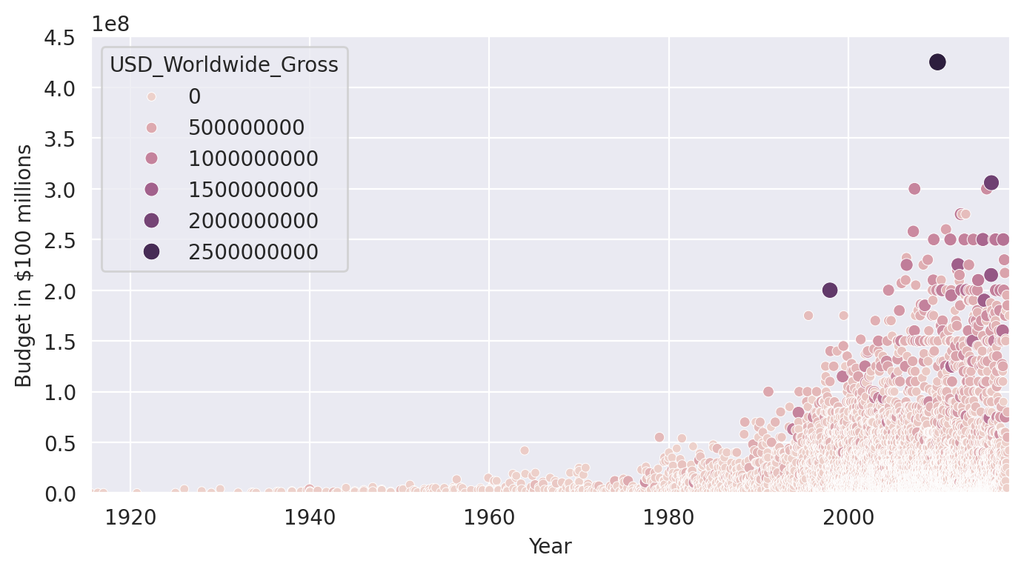

[figure not shown]

# Grouping Releases by Decade

Derive a `Decade` column using floor division so films can be grouped and compared across eras.

|  | Rank | Release_Date | Movie_Title | USD_Production_Budget | USD_Worldwide_Gross | USD_Domestic_Gross | Decade |
| --- | --- | --- | --- | --- | --- | --- | --- |
| 0 | 5293 | 1915-08-02 | The Birth of a Nation | 110000 | 11000000 | 10000000 | 1910 |
| 1 | 5140 | 1916-05-09 | Intolerance | 385907 | 0 | 0 | 1910 |
| 2 | 5230 | 1916-12-24 | 20,000 Leagues Under the Sea | 200000 | 8000000 | 8000000 | 1910 |
| 3 | 5299 | 1920-09-17 | Over the Hill to the Poorhouse | 100000 | 3000000 | 3000000 | 1920 |
| 4 | 5222 | 1925-01-01 | The Big Parade | 245000 | 22000000 | 11000000 | 1920 |

### Splitting the Dataset by Era

Separate pre-1970 films from modern films to compare how the budget-to-revenue relationship differs across eras.

```
Number of old films: 153
Number of new films: 5231
```

|  | Rank | Release_Date | Movie_Title | USD_Production_Budget | USD_Worldwide_Gross | USD_Domestic_Gross | Decade |
| --- | --- | --- | --- | --- | --- | --- | --- |
| 153 | 2159 | 1970-01-01 | Waterloo | 25000000 | 0 | 0 | 1970 |
| 154 | 2270 | 1970-01-01 | Darling Lili | 22000000 | 5000000 | 5000000 | 1970 |
| 155 | 3136 | 1970-01-01 | Patton | 12000000 | 62500000 | 62500000 | 1970 |
| 156 | 3277 | 1970-01-01 | The Molly Maguires | 11000000 | 2200000 | 2200000 | 1970 |
| 157 | 4265 | 1970-01-01 | M*A*S*H | 3500000 | 81600000 | 81600000 | 1970 |

# Seaborn Regression Plots

### Regression Line: Films from 1970 Onwards

Fit and visualise the linear relationship between budget and worldwide revenue for the modern film era.

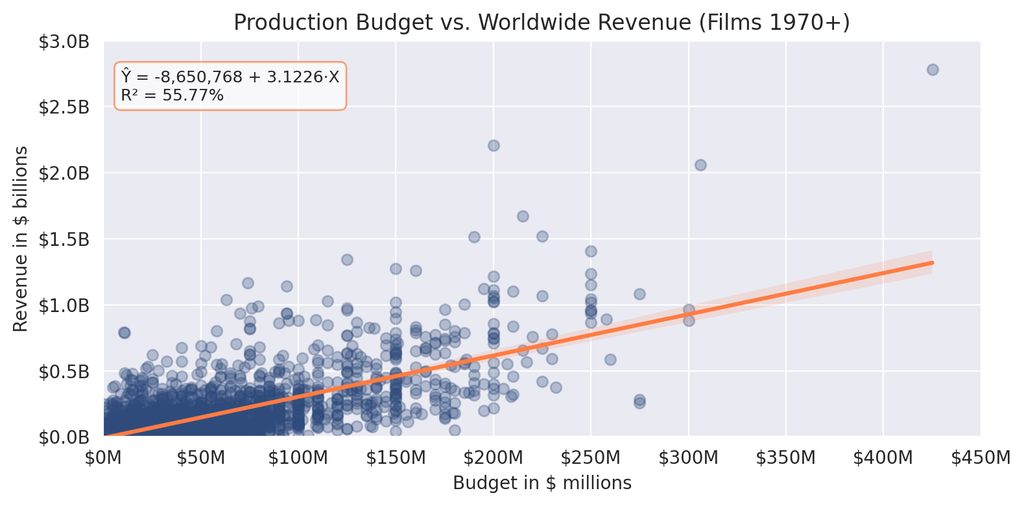

# Run Your Own Regression with scikit-learn

$$ REV \hat ENUE = \theta _0 + \theta _1 BUDGET$$

```
LinearRegression()
```

```
array([-8650768.00661096])
```

```
array([[3.12259592]])
```

```
The model explains 55.77% of the variance
```

### Regression for Pre-1970 Films

Repeat the regression on old films to compare slope, intercept, and explanatory power against the modern era model.

```
LinearRegression()
```

```
The slope coefficient is 1.6477131440107315
THe intercept is 22821538.635080386
```

# Estimating Revenue from Budget

With slope and intercept in hand, the model equation can generate a point prediction for any given budget.

$$ REV\hat{ENUE} = \theta_0 + \theta_1 \cdot BUDGET $$

```
The estimated revenue of a $350 million budget is $599,521,139
```

# Key Findings

- **Production budget explains 55.77% of the variance in worldwide revenue** for films released from 1970 onwards (R² = 0.5577).
- **Every $1 of production budget is associated with ~$3.12 in worldwide gross** (slope = 3.1226) for the modern era.
- **37.28% of all released films failed to recoup their production costs** from worldwide box-office revenue.
- **357 films reported zero worldwide gross**, including several with budgets above $60M — many were unreleased or streaming-only at the time of data collection.
- **155 international releases** earned worldwide revenue while recording zero domestic (US) gross.
- The highest-budget film in the dataset is Avatar ($425M budget), which grossed $2.78B worldwide — more than 6× its production cost.
- The lowest-budget film is My Date With Drew ($1,100 budget, 2005), which grossed $181,041 — a return of over 160×.
- Pre-1970 films show a weaker and shallower budget-to-revenue relationship (slope ≈ 1.65) compared to the modern era, reflecting structural differences in distribution and market scale.